# generics-hierarchicalprior

mht

July 12, 2015

# Hierarchical prior elicitation

Two question prior elicitation task.

1. How likely is it that *glippet* has F?
2. Given that there is a glippet with F, what % of glippets have F?

The idea is that question 1 gets us the prevalence *across categories* and question 2 gets us the prevalence *within categories*.

I decided upon this design as opposed to our previous design because of customer satisfaction. The earlier design was very confusing (as evident in the self-report). This design I believe is a lot less confusing (and in the “Do you understand?” question, everyone said “Yes”).

The experiment can be viewed [here](http://stanford.edu/~mtessler/generics/experiments/asymmetry/prior-2.html).

I used 4 types of properties:

1. Accidental (e.g. broken legs)
2. Color (e.g. yellow legs)
3. Part (e.g. legs)
4. Vague (e.g. long legs)

#### Sanity check

Do participants answer the 2 questions differently?

Plotted below are the trial-wise responses to the 2 questions (question 1 on x-axis, question 2 on y-axis). I added some jitter to the points to see more clearly what’s going on.

```r
library(VGAM)
```

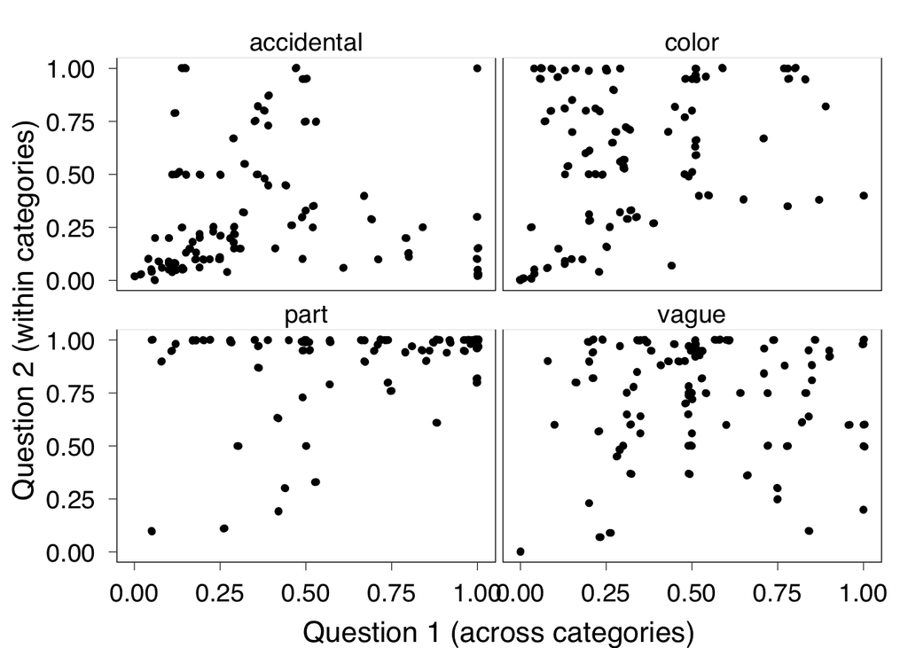

```r
d<-read.csv('~/Documents/research/generics/experiments/turk/asymmetry-prior-2/asymmetry-prior-2-trials.csv')

ggplot(data=d,aes(x=response0,y=response1))+
  geom_point()+
  geom_jitter(position = position_jitter())+
  facet_wrap(~stim_type)+
  xlab("Question 1 (across categories)")+
  ylab("Question 2 (within categories)")
```

Accidental properties are showing a bit of a correlation in the responses, but this is perhaps expected.

One concern overall is that answers to question 1 aren’t low enough (most things don’t have most things), but it’s hard to say. Even so, it could be a miscalibration with the slider bar that a linking function could resolve.

### Raw data density plots

[output not shown]

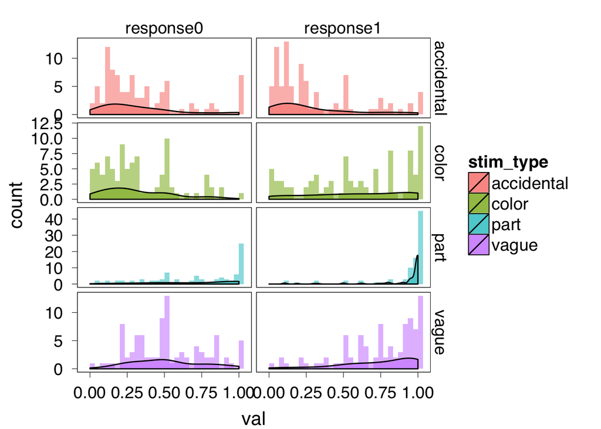

```r
d.tidy <- d %>%
  select(stim_type,response0,response1,stim_property) %>%
  gather(resp, val, response0,response1)

ggplot(d.tidy, aes(x=val,fill=stim_type))+
  geom_histogram(alpha=0.5)+
  geom_density(alpha=0.5)+
  facet_grid(stim_type~resp, scales='free')
```

**Note: scales=‘free’ so the y-axis is different across plots. This is to improve visual clarity but be careful doing visual-quantitative comparisons across plots.**

This also looks reasonable.

Parts are highly generalizable, though less so across categories (response0 vs. response1).

Accidental properties are rare both within and across categories.

Color properties are rare across categories (response0) but pretty generalizable within (response1).

Vague properties are somewhat more common across categories than the color and accidental properties, and also pretty generalizable within categories.

## Inferred betas

I wrote a bayesian data analysis model in webppl, found [here](https://github.com/mhtess/generics/blob/master/analysis/FBT-priors/FBT-hierarchicalPrior.wppl).

The model infers the parameters of a beta distribution, one for each question X property_type. (Analagous to the raw distribution seen above.) Here are the results.

Below, I’m doing *the poor man’s posterior predictive*. I took the expected value of the posteriors over parameters, and am using those values to generate each plot.

These expected values are highly replicable. (done with 10,000 iterations on IncrementalMH)

```
## [1] "expected values of posteriors"
```

```
## Source: local data frame [8 x 6]
## Groups: condition, response
##
##    condition  response  gamma delta      a      b
## 1 accidental response0 0.3943 1.990 0.7847 1.2054
## 2 accidental response1 0.3637 1.847 0.6719 1.1754
## 3       part response0 0.7073 1.630 1.1528 0.4771
## 4       part response1 0.8662 3.050 2.6416 0.4081
## 5      vague response0 0.5399 2.816 1.5202 1.2954
## 6      vague response1 0.7237 2.132 1.5432 0.5891
## 7      color response0 0.3343 2.983 0.9974 1.9861
## 8      color response1 0.5829 1.271 0.7410 0.5303
```

[output not shown]

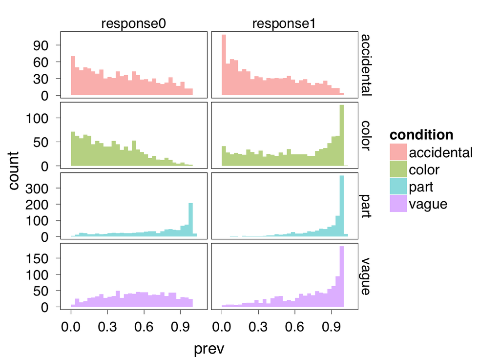

**Note: scales=‘free’ so the y-axis is different across plots. This is to improve visual clarity but be careful doing visual-quantitative comparisons across plots.**

This looks like a cleaned-up version of the raw data.

#### Generated prevalence priors

Using again the expected values of the posteriors over parameters, I generate the prevalence priors that we’ve been using in the RSA model.

The logic is:

1. Sample an *across-category prevalence* (response 0)
2. flip that coin
3. If heads (the category has at least one member with the property), sample a *within-category prevalence* (response 1)
4. If tails, return 0

[output not shown]

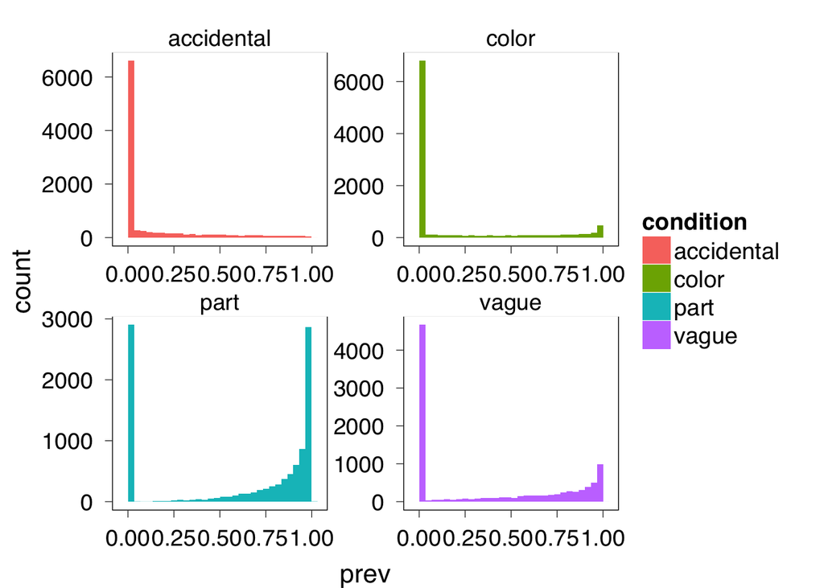

Again, we see the parts are highly generalizable. Vague properties a little less so. Color properties a little less so. And accidental properties not at all. Let’s remove the 0 responses to zoom in the non-zero part of the distribution.

[output not shown]

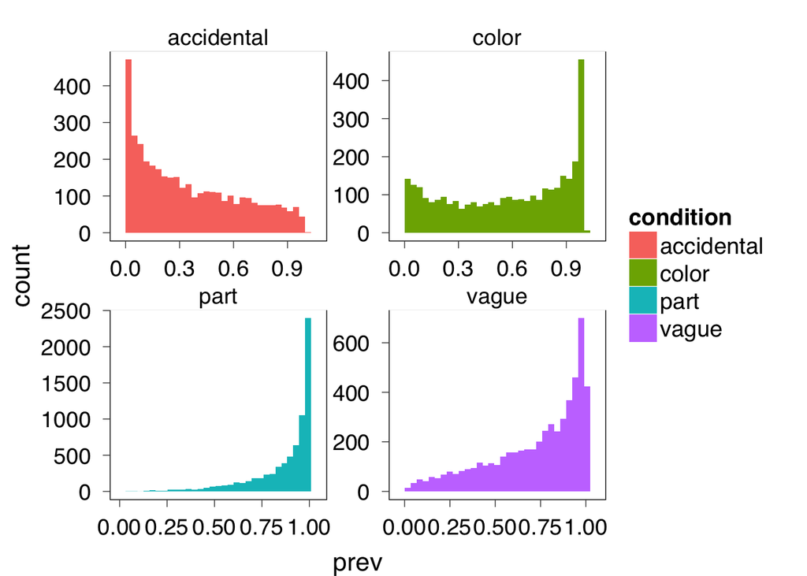